# Users Ride pattern in Ford GoBike System

## Investigation Overview

In this investigation, We wanted to look at the characteristics of Ford GoBike system rides that could influence the likelihood of a user being a subscriber to the Customer. This will help the Company to create strategies to develop their subscription base users.

## Dataset Overview

The dataset used for this exploratory analysis consists of monthly individual trip data from January to December 2019.  
We gathered the data directly from [Lyft System Data website](https://s3.amazonaws.com/baywheels-data/index.html) and we performed some important steps of data cleaning to include only useful features in the exploratory analysis.

## Distribution of Trips Duration

The Duration of Trips in the dataset take on a large range of values, from about **1 minutes** at the lowest end, to about **1400 minutes** at the highest end. We limited the data to only trips less then one hour this made the distribution skewed to the right with long tail up to 60 minutes.

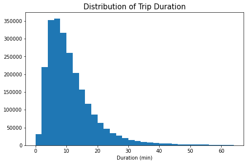

```python
plt.figure(figsize=[8, 5])
bins = np.arange(0, 66, 2)

plt.hist(data=df_clean, x='duration_min', bins=bins)
plt.title('Distribution of Trip Duration', fontsize=15)
plt.xlabel('Duration (min)');
plt.show();
```

## Distribution of Trips Distance

For the distance variable the users tend to ride bikes within a distance of 10 kilometers, with an occurrence of significant amounts of outliers, limiting the data to show only trips less then 10 km gives a nice right skewed distribution with gradually decreasing frequencies.

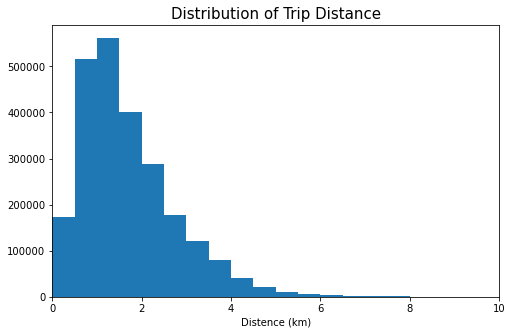

```python
plt.figure(figsize=[8, 5])
bins = np.arange(0,10+.1, 0.5)

plt.hist(data = df_clean, x = 'distance_km',bins=bins)
plt.title('Distribution of Trip Distance', fontsize=15)
plt.xlim(0,10)
plt.xlabel('Distence (km)')
plt.show();
```

# User Types and Their Monthly Rides

[figure not shown]

```python
plt.figure(figsize=[16, 6]);
base_color = sb.color_palette()[0];

plt.subplot(1, 2, 1);
sb.countplot(data=df_clean, x='user_type');
plt.yticks([25e4, 50e4, 75e4, 100e4, 125e4, 150e4, 175e4, 200e4], [ '250,000','500,000', '750,000', '1,000,000','1,250,000', '1,500,000', '1,750,000', '2,000,000']);
plt.xlabel('User Type')
plt.ylabel('Number of bike trips')


plt.subplot(1, 2, 2);
sb.countplot(data=df_clean,x='start_month',hue='user_type')
plt.xticks(rotation=45)
plt.xlabel('start month')
plt.ylabel('')
plt.legend(loc = 6, bbox_to_anchor = (1.0, 0.5))

plt.suptitle('User Types and their Monthly Rides', fontsize=15);
```

# Daily Ride Duration by User Type

Customers use the bike share system for a relatively long period of time on weekdays, with a significant increase on weekends. In the other hand, subscribers have sustained usage in weekdays with a gradual increase in weekends.

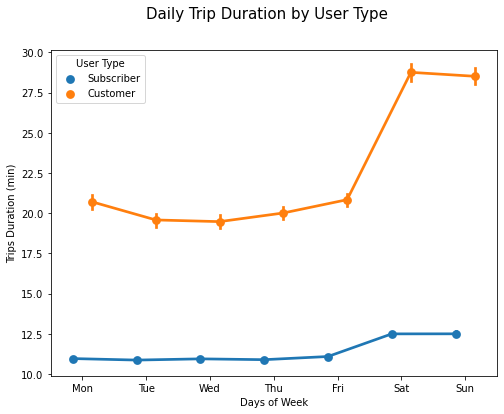

```python
plt.figure(figsize = [8, 6])
sb.pointplot(data=df_clean, x='start_dayofweek', y='duration_min', hue='user_type', dodge=0.3);
plt.xlabel('Days of Week');
plt.ylabel('Trips Duration (min)')
plt.legend(title='User Type')
plt.suptitle('Daily Trip Duration by User Type', fontsize=15);
plt.show();
```

# Hourly Usage on days of week for Customers and Subscribers

Both Customers and Subscribers use the bike share system colossally during commuting hours (07-09AM and 16-18PM) on weekdays.  
Additionally, weekday and commute time greatly influences the likelihood of a trip being a subscriber. Particularly, if a bike ride is on a weekday, the trip is more likely to be made by a subscriber than a customer. Similarly, a trip during the commute hours is more likely to be from a subscriber than not. With this information, we say that during weekdays and commute hours, there demand will be at a consistent level due to the subscribers tending to be the most frequent users.

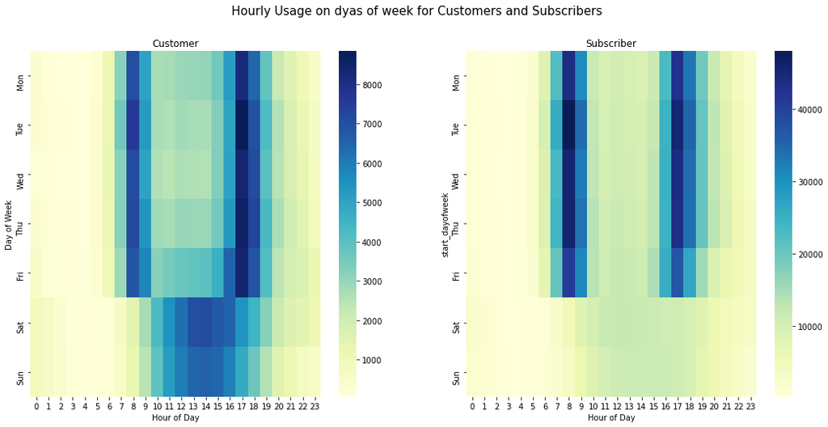

```python
fig, ax = plt.subplots(ncols = 2, figsize = [18,8])



plt.subplot(1, 2, 1)
customers = df_clean.query('user_type == "Customer"')
ct_counts = customers.groupby(['start_dayofweek', 'start_hour']).size()
ct_counts = ct_counts.reset_index(name='count')
ct_counts = ct_counts.pivot(index='start_dayofweek', columns='start_hour', values='count')
sb.heatmap(ct_counts, cmap='YlGnBu')
plt.title('Customer', loc='center')
plt.xlabel('Hour of Day')
plt.ylabel('Day of Week');

plt.subplot(1, 2, 2)
subscribers = df_clean.query('user_type == "Subscriber"')
st_counts = subscribers.groupby(['start_dayofweek', 'start_hour']).size()
st_counts = st_counts.reset_index(name='count')
st_counts = st_counts.pivot(index='start_dayofweek', columns='start_hour', values='count')
sb.heatmap(st_counts, cmap='YlGnBu')
plt.title('Subscriber', loc='center')
plt.xlabel('Hour of Day')

plt.suptitle('Hourly Usage on dyas of week for Customers and Subscribers',fontsize=15);
```